# Exercise 4

Author

Gonzalo Cardenal (GonzaloCardenalAl)

Published

October 16, 2023

## Load packages

```r
library(limma) # replace this with packages you will use
library(ggplot2)
library(pheatmap)
library(ROCR)
```

## Run some things

```r
nGenes <- 10000                   # number of "features"
nSamples <- 6                     # number of samples (split equal in 2 groups)
pDiff <- .1                       # percent of genes "differential"
grp <- rep(0:1,each=nSamples/2)   # dummy variable for exp. group
trueFC <- 2                       # log-fold-change of truly DE

d0 <- 1. #degrees of freedom
s0 <- 0.8
sd <- s0*sqrt(d0/rchisq(nGenes,df=d0))  # dist'n of s.d.

y <- matrix(rnorm(nGenes*nSamples,sd=sd),
            nr=nGenes,nc=nSamples)

indD <- 1:floor(pDiff*nGenes)
diff <- sample(c(-1,1),max(indD),replace=TRUE)*trueFC
y[indD,grp==1] <- y[indD,grp==1] + diff
```

## Question 1

*First, do an exploratory analysis of the true (simulated) and observed (calculated from data) variances. For the observed variances, compute the residual variance for each row of y (i.e., pooled variance of the two groups of simulated samples, not the row-wise variance; see the denominator of the classical two-sample t-statistic) and look at the distribution of them, of the true variances (from the simulated sd) and make a scatter plot of true versus observed. Often, viewing variances on the log scale is preferred.*

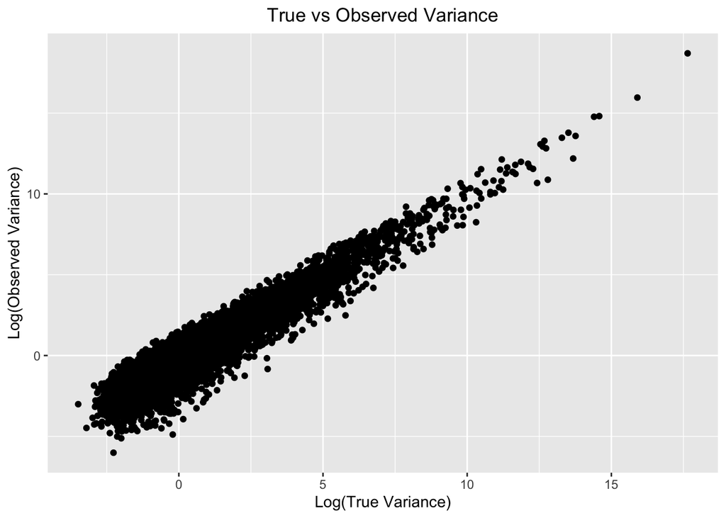

```r
truevar=sd**2

#We compute residual variance
rvar <- numeric(nrow(y))
for (i in 1:nrow(y)){
  g0 <- y[i, grp == 0]
  g1 <- y[i, grp == 1]

  var0 <- var(g0)
  var1 <- var(g1)

  n0 <- sum(grp == 0)
  n1 <- sum(grp == 1)

  pooledvar <- ((n0 -1)*var0 + (n1 -1)* var1)/ (n0 + n1 -2)
  rvar[i] <- pooledvar
}

variance_df <- data.frame(TrueVar = truevar, ObservedVar = rvar)

ggplot(variance_df, aes(x = log(TrueVar), y = log(ObservedVar))) +
          geom_point() +
          labs(x = "Log(True Variance)", y = "Log(Observed Variance)") +
          ggtitle("True vs Observed Variance") +
          theme(plot.title = element_text(hjust = 0.5))
```

## Question 2

*Produce a visualization that demonstrates that you understand the “differential expression” that we introduced into the simulation. There are many possibilities; use your creativity.*

We can plot a heatmap of the average normalised expression of each gene for each group.

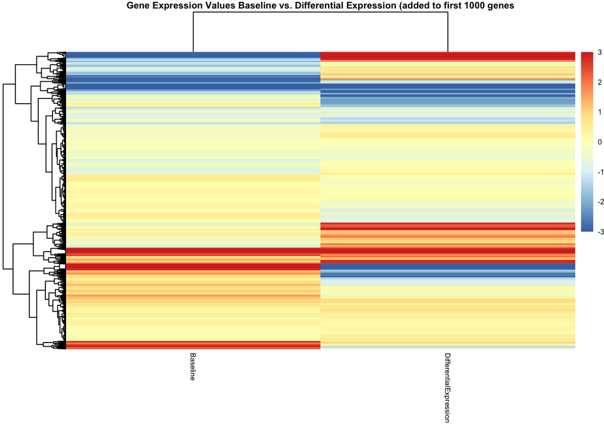

```r
normalised_g0 <- rowMeans(y[,grp == 0])
normalised_g1 <- rowMeans(y[,grp == 1])

normalised_g0[normalised_g0 > 3] = 3
normalised_g0[normalised_g0 < -3] = -3
normalised_g1[normalised_g1 > 3] = 3
normalised_g1[normalised_g1 < -3] = -3

averaged_expression_df <- data.frame(Baseline = normalised_g0,
                                      DifferentialExpression = normalised_g1)

pheatmap(averaged_expression_df, show_rownames = FALSE, treeheight_row = 50, treeheight_col = 30, fontsize = 6, main = "Gene Expression Values Baseline vs. Differential Expression (added to first 1000 genes")
```

In the heatmap we can clearly see the difference of two Fold change in the expression values between each group. For the first 1000 genes, expression values are flipped. Values were cropped to [-3,3] to be able to visualize the differences in the presence of outliers.

## Question 3

Next, we create a design matrix to represent the linear model to be fitted (to each row of the table):

```r
(design <- model.matrix(~grp))
```

```
  (Intercept) grp
1           1   0
2           1   0
3           1   0
4           1   1
5           1   1
6           1   1
attr(,"assign")
[1] 0 1
```

*In practical terms, what is the interpretation of the two columns of the design matrix with the parameterization shown above?*

The number of rows is equivalent to the number of samples for each group, and the two columns determined the meaning that each parameter of the linear model will have. Because the first column is 1 and the second 0, the ß1 will mean the average expression of group 0. For the second group the parameter will denote the change between the group 1 (DE)- group 0. The linear model will fit and have each own parameters for each gene. This type of design matrix is based on the “Mean-reference model”.

## Question 4

```r
fit <- lmFit(y,design)
fit <- eBayes(fit)

names(fit)
```

```
 [1] "coefficients"     "rank"             "assign"           "qr"
 [5] "df.residual"      "sigma"            "cov.coefficients" "stdev.unscaled"
 [9] "pivot"            "Amean"            "method"           "design"
[13] "df.prior"         "s2.prior"         "var.prior"        "proportion"
[17] "s2.post"          "t"                "df.total"         "p.value"
[21] "lods"             "F"                "F.p.value"
```

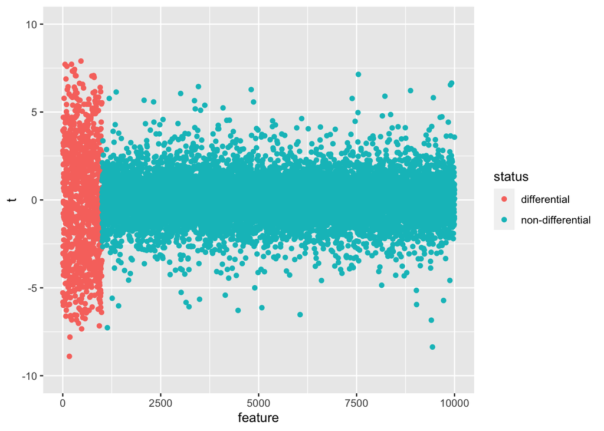

```r
cols <- rep("non-differential",nrow(y))
cols[indD] <- "differential"

df <- data.frame(feature=1:length(cols),
                 t=fit$t[,2],
                 status=cols)

ggplot(df, aes(x=feature, y=t, colour=status)) +
  geom_point() + ylim(-10,10)
```

*For each row (each feature in the experiment) of y, calculate the classical 2-sample t-test. See ?t.test for more details about the built-in R function to do this calculation and convince yourself which arguments to use to match the classical t-test described in the lecture. Add a visualization similar to the above plot for the classical t-statistic and the log-fold-change (mean difference of the 2 groups). By eye, which statistic best separates the truly differential from non-differential?*

We run a two-sample t-test with unique variance

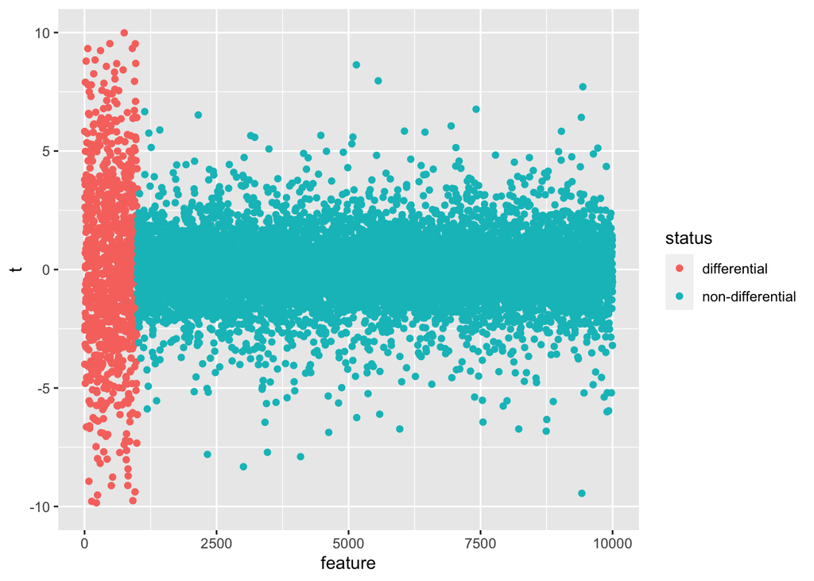

```r
t <-numeric(nrow(y))
for (i in 1:nrow(y)){
  ttest <-  t.test(x= y[i, grp == 0], y= y[i, grp == 1], var.equal = TRUE)
  t[i] <- ttest$statistic
}
meandiff <- rowMeans(y[,grp == 1]) - rowMeans(y[, grp == 0])
df_classicfit <- data.frame(feature=1:length(cols),
                 t=t,
                 FC = meandiff,
                 status=cols)

ggplot(df_classicfit, aes(x=feature, y=t, colour=status)) +
  geom_point() +
  ylim(-10,10)
```

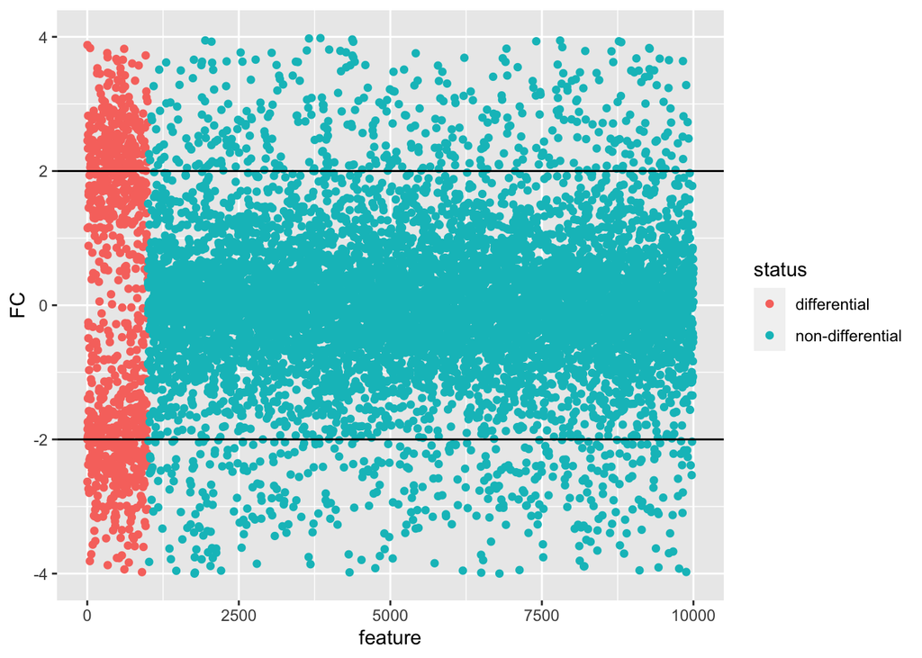

```r
ggplot(df_classicfit, aes(x=feature, y=FC, colour=status)) +
  geom_point() +
  ylim(-4, +4) +
  geom_hline(yintercept=2) +
  geom_hline(yintercept = -2)
```

Both statistics, although substantially noisy, allow to visualize differential expression. In the the case of the log-fold-change the DE can be seen slightly easier by eye, as we can see the points denoting differential expression are between +2,-2.

## Question 5

*Pick a reasonable metric to compare the methods, such as an ROC curve, false discovery plot, power versus achieved FDR. Using this metric / curve, formally compare the performance of the classical t-test (calculated in Question 4), the moderated t-test (plotted above) and the log-fold-change or mean difference (fit$coef). Two packages that are useful for these kind of plots include: ROCR or iCOBRA.*

```r
# create the predictions
pred_classic <- prediction(abs(df_classicfit$t), df_classicfit$status, label.ordering = c("non-differential", "differential"))
pred_moderated <- prediction(abs(df$t), df$status, label.ordering = c("non-differential", "differential"))
pred_FC <- prediction(abs(df_classicfit$FC), df_classicfit$status, label.ordering = c("non-differential", "differential"))

#get the metrics
perf_classic <- performance(pred_classic, "tpr", "fpr")
perf_moderated <- performance(pred_moderated, "tpr", "fpr")
perf_FC <- performance(pred_FC, "tpr", "fpr")

#AUC of each method
AUC_classic <-  performance(pred_classic, "auc")
AUC_moderated <-performance(pred_moderated, "auc")
AUC_FC <- performance(pred_FC, "auc")

print(paste("The AUC values where:", round(AUC_classic@y.values[[1]],3), round(AUC_moderated@y.values[[1]],3), round(AUC_FC@y.values[[1]],3), "for Classic t-test, Moderated t-test and Log-Folg-Change respectively"))
```

```
[1] "The AUC values where: 0.789 0.809 0.779 for Classic t-test, Moderated t-test and Log-Folg-Change respectively"
```

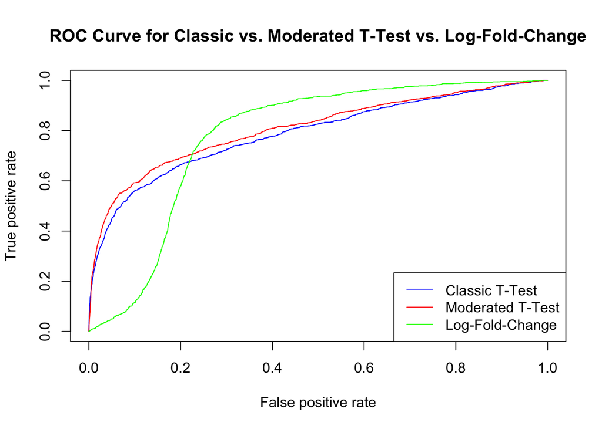

```r
#plot the ROCs
plot(perf_classic, col = "blue", main = "ROC Curve for Classic vs. Moderated T-Test vs. Log-Fold-Change")
plot(perf_moderated, col = "red", add = TRUE)
plot(perf_FC, col="green", add= TRUE)

# Add a legend to the plot
legend("bottomright", legend = c("Classic T-Test", "Moderated T-Test", "Log-Fold-Change"), col = c("blue", "red", "green"), lty = 1)
```

The AUC values obtained indicate that the Moderated t-test yields the best predictions, followed by the Classic t-test and the Log-Fold-Change. However, when examining the plot, the Log-Fold-Change performs better after surpassing the false positive rate (FPR) at around 0.23.